# Predict Bike Sharing Demand with AutoGluon Template

## Project: Predict Bike Sharing Demand with AutoGluon

This notebook is a template with each step that you need to complete for the project.

Please fill in your code where there are explicit `?` markers in the notebook. You are welcome to add more cells and code as you see fit.

Once you have completed all the code implementations, please export your notebook as a HTML file so the reviews can view your code. Make sure you have all outputs correctly outputted.

`File-> Export Notebook As... -> Export Notebook as HTML`

There is a writeup to complete as well after all code implememtation is done. Please answer all questions and attach the necessary tables and charts. You can complete the writeup in either markdown or PDF.

Completing the code template and writeup template will cover all of the rubric points for this project.

The rubric contains "Stand Out Suggestions" for enhancing the project beyond the minimum requirements. The stand out suggestions are optional. If you decide to pursue the "stand out suggestions", you can include the code in this notebook and also discuss the results in the writeup file.

## Step 1: Create an account with Kaggle

### Create Kaggle Account and download API key

Below is example of steps to get the API username and key. Each student will have their own username and key.

1. Open account settings.

2. Scroll down to API and click Create New API Token.

3. Open up `kaggle.json` and use the username and key.


## Step 2: Download the Kaggle dataset using the kaggle python library

### Open up Sagemaker Studio and use starter template

1. Notebook should be using a `ml.t3.medium` instance (2 vCPU + 4 GiB)
2. Notebook should be using kernal: `Python 3 (MXNet 1.8 Python 3.7 CPU Optimized)`

### Install packages

```python
!pip install -U pip
!pip install -U setuptools wheel
!pip install -U "mxnet<2.0.0" bokeh==2.0.1
!pip install autogluon --no-cache-dir
# Without --no-cache-dir, smaller aws instances may have trouble installing
```

[output not shown]

[output cut: 17 more lines]

[output not shown]

### Download and explore dataset

```python
# Create a kaggle directory
!mkdir -p ~/.kaggle # Using -p ensures no error if the directory already exists

# Copy 'kaggle.json' (Kaggle API Token) to the folder we have created
!cp kaggle.json ~/.kaggle/

# Authorize permissions for the json to act
!chmod 600 ~/.kaggle/kaggle.json

# Download the Bike Sharing Demand dataset
!kaggle competitions download -c bike-sharing-demand

# Unzip Dataset
!unzip -o bike-sharing-demand.zip

# Download the dataset, it will be in a .zip file so you'll need to unzip it as well.
!kaggle competitions download -c bike-sharing-demand
# If you already downloaded it you can use the -o command to overwrite the file
!unzip -o bike-sharing-demand.zip
```

```
Downloading bike-sharing-demand.zip to /home/sagemaker-user/udacity-AWS-ml-engineer-nanodegree/project
Archive:  bike-sharing-demand.zip
  inflating: sampleSubmission.csv
  inflating: test.csv
  inflating: train.csv
bike-sharing-demand.zip: Skipping, found more recently modified local copy (use --force to force download)
Archive:  bike-sharing-demand.zip
  inflating: sampleSubmission.csv
  inflating: test.csv
  inflating: train.csv
```

### Go to the bike sharing demand competition and agree to the terms

```python
import numpy as np
import pandas as pd
from autogluon.tabular import TabularPredictor
```

```python
# Create the train dataset in pandas by reading the csv
# Set the parsing of the datetime column so you can use some of the `dt` features in pandas later
train = pd.read_csv("train.csv",parse_dates=["datetime"])
train.head()
```

|  | datetime | season | holiday | workingday | weather | temp | atemp | humidity | windspeed | casual | registered | count |
| --- | --- | --- | --- | --- | --- | --- | --- | --- | --- | --- | --- | --- |
| 0 | 2011-01-01 00:00:00 | 1 | 0 | 0 | 1 | 9.84 | 14.395 | 81 | 0.0 | 3 | 13 | 16 |
| 1 | 2011-01-01 01:00:00 | 1 | 0 | 0 | 1 | 9.02 | 13.635 | 80 | 0.0 | 8 | 32 | 40 |
| 2 | 2011-01-01 02:00:00 | 1 | 0 | 0 | 1 | 9.02 | 13.635 | 80 | 0.0 | 5 | 27 | 32 |
| 3 | 2011-01-01 03:00:00 | 1 | 0 | 0 | 1 | 9.84 | 14.395 | 75 | 0.0 | 3 | 10 | 13 |
| 4 | 2011-01-01 04:00:00 | 1 | 0 | 0 | 1 | 9.84 | 14.395 | 75 | 0.0 | 0 | 1 | 1 |

```python
# Simple output of the train dataset to view some of the min/max/varition of the dataset features.
# Train dataset summary
train.describe()
```

|  | datetime | season | holiday | workingday | weather | temp | atemp | humidity | windspeed | casual | registered | count |
| --- | --- | --- | --- | --- | --- | --- | --- | --- | --- | --- | --- | --- |
| count | 10886 | 10886.000000 | 10886.000000 | 10886.000000 | 10886.000000 | 10886.00000 | 10886.000000 | 10886.000000 | 10886.000000 | 10886.000000 | 10886.000000 | 10886.000000 |
| mean | 2011-12-27 05:56:22.399411968 | 2.506614 | 0.028569 | 0.680875 | 1.418427 | 20.23086 | 23.655084 | 61.886460 | 12.799395 | 36.021955 | 155.552177 | 191.574132 |
| min | 2011-01-01 00:00:00 | 1.000000 | 0.000000 | 0.000000 | 1.000000 | 0.82000 | 0.760000 | 0.000000 | 0.000000 | 0.000000 | 0.000000 | 1.000000 |
| 25% | 2011-07-02 07:15:00 | 2.000000 | 0.000000 | 0.000000 | 1.000000 | 13.94000 | 16.665000 | 47.000000 | 7.001500 | 4.000000 | 36.000000 | 42.000000 |
| 50% | 2012-01-01 20:30:00 | 3.000000 | 0.000000 | 1.000000 | 1.000000 | 20.50000 | 24.240000 | 62.000000 | 12.998000 | 17.000000 | 118.000000 | 145.000000 |
| 75% | 2012-07-01 12:45:00 | 4.000000 | 0.000000 | 1.000000 | 2.000000 | 26.24000 | 31.060000 | 77.000000 | 16.997900 | 49.000000 | 222.000000 | 284.000000 |
| max | 2012-12-19 23:00:00 | 4.000000 | 1.000000 | 1.000000 | 4.000000 | 41.00000 | 45.455000 | 100.000000 | 56.996900 | 367.000000 | 886.000000 | 977.000000 |
| std | NaN | 1.116174 | 0.166599 | 0.466159 | 0.633839 | 7.79159 | 8.474601 | 19.245033 | 8.164537 | 49.960477 | 151.039033 | 181.144454 |

```python
# Information of the feature datatypes
train.info()
```

```
<class 'pandas.core.frame.DataFrame'>
RangeIndex: 10886 entries, 0 to 10885
Data columns (total 12 columns):
 #   Column      Non-Null Count  Dtype
---  ------      --------------  -----
 0   datetime    10886 non-null  datetime64[ns]
 1   season      10886 non-null  int64
 2   holiday     10886 non-null  int64
 3   workingday  10886 non-null  int64
 4   weather     10886 non-null  int64
 5   temp        10886 non-null  float64
 6   atemp       10886 non-null  float64
 7   humidity    10886 non-null  int64
 8   windspeed   10886 non-null  float64
 9   casual      10886 non-null  int64
 10  registered  10886 non-null  int64
 11  count       10886 non-null  int64
dtypes: datetime64[ns](1), float64(3), int64(8)
memory usage: 1020.7 KB
```

```python
# Check for the count of missing values
train.isnull().sum()
```

```
datetime      0
season        0
holiday       0
workingday    0
weather       0
temp          0
atemp         0
humidity      0
windspeed     0
casual        0
registered    0
count         0
dtype: int64
```

```python
# Create the test pandas dataframe in pandas by reading the csv, remember to parse the datetime!
test = pd.read_csv("test.csv",parse_dates=["datetime"])
test.head()
```

|  | datetime | season | holiday | workingday | weather | temp | atemp | humidity | windspeed |
| --- | --- | --- | --- | --- | --- | --- | --- | --- | --- |
| 0 | 2011-01-20 00:00:00 | 1 | 0 | 1 | 1 | 10.66 | 11.365 | 56 | 26.0027 |
| 1 | 2011-01-20 01:00:00 | 1 | 0 | 1 | 1 | 10.66 | 13.635 | 56 | 0.0000 |
| 2 | 2011-01-20 02:00:00 | 1 | 0 | 1 | 1 | 10.66 | 13.635 | 56 | 0.0000 |
| 3 | 2011-01-20 03:00:00 | 1 | 0 | 1 | 1 | 10.66 | 12.880 | 56 | 11.0014 |
| 4 | 2011-01-20 04:00:00 | 1 | 0 | 1 | 1 | 10.66 | 12.880 | 56 | 11.0014 |

```python
# Similar Check for the count of missing values in test data
train.isnull().sum()
```

```
datetime      0
season        0
holiday       0
workingday    0
weather       0
temp          0
atemp         0
humidity      0
windspeed     0
casual        0
registered    0
count         0
dtype: int64
```

```python
# Shape of the train and test data
print("Train Shape : ", train.shape)
print("Test Shape  : ", test.shape)
```

```
Train Shape :  (10886, 12)
Test Shape  :  (6493, 9)
```

```python
# List all the features in train and test data to identify features that can be safely removed
print("Features in Training data:\n", train.columns)
print("\nFeatures in Testing data:\n", test.columns)
```

```
Features in Training data:
 Index(['datetime', 'season', 'holiday', 'workingday', 'weather', 'temp',
       'atemp', 'humidity', 'windspeed', 'casual', 'registered', 'count'],
      dtype='object')

Features in Testing data:
 Index(['datetime', 'season', 'holiday', 'workingday', 'weather', 'temp',
       'atemp', 'humidity', 'windspeed'],
      dtype='object')
```

```python
# Thus missing features are
print("Missing features are")
list(set(train.columns).difference(set(test.columns)))
```

```
Missing features are
```

```
['count', 'registered', 'casual']
```

### Dataset Dictionary

**temp** - temperature in Celsius  
**atemp** - "feels like" temperature in Celsius  
**humidity** - relative humidity  
**windspeed** - wind speed  
**casual** - number of non-registered user rentals initiated (removed)  
**registered** - number of registered user rentals initiated (removed)  
**count** - number of total rentals  
**datetime** - hourly date + timestamp  
**season** - 1 = spring, 2 = summer, 3 = fall, 4 = winter  
**holiday** - whether the day is considered a holiday  
**workingday** - whether the day is neither a weekend nor holiday  
**weather** -

1: Clear, Few clouds, Partly cloudy, Partly cloudy  
2: Mist + Cloudy, Mist + Broken clouds, Mist + Few clouds, Mist  
3: Light Snow, Light Rain + Thunderstorm + Scattered clouds, Light Rain + Scattered clouds  
4: Heavy Rain + Ice Pallets + Thunderstorm + Mist, Snow + Fog

```python
# Same thing as train and test dataset
submission = pd.read_csv("sampleSubmission.csv",parse_dates=["datetime"])
submission.head()
```

|  | datetime | count |
| --- | --- | --- |
| 0 | 2011-01-20 00:00:00 | 0 |
| 1 | 2011-01-20 01:00:00 | 0 |
| 2 | 2011-01-20 02:00:00 | 0 |
| 3 | 2011-01-20 03:00:00 | 0 |
| 4 | 2011-01-20 04:00:00 | 0 |

## Step 3: Train a model using AutoGluon’s Tabular Prediction

Requirements:

- We are prediting `count`, so it is the label we are setting.
- Ignore `casual` and `registered` columns as they are also not present in the test dataset.
- Use the `root_mean_squared_error` as the metric to use for evaluation.
- Set a time limit of 10 minutes (600 seconds).
- Use the preset `best_quality` to focus on creating the best model.

```python
# Requirements:
label = 'count'
ignored_columns = ["casual", "registered"]   # Ignored columns during training
eval_metric = 'root_mean_squared_error'
time_limit = 600                             # 10 minutes that is 600 seconds
train_data = train
presets = "best_quality"
```

```python
predictor = TabularPredictor(label=label,
problem_type= 'regression',
eval_metric=eval_metric,
learner_kwargs={'ignored_columns': ignored_columns}).fit(
    train_data = train_data,
    time_limit=time_limit,
    presets=presets)
```

[output not shown]

[output cut: 34 more lines]

[output not shown]

```
(_ray_fit pid=2215) [1000]	valid_set's rmse: 132.725
```

[output not shown]

```
(_ray_fit pid=2279) [1000]	valid_set's rmse: 128.154
(_ray_fit pid=2318) [1000]	valid_set's rmse: 135.845
```

[output not shown]

```
(_ray_fit pid=2357) [1000]	valid_set's rmse: 137.712 [repeated 4x across cluster]
(_ray_fit pid=2357) [5000]	valid_set's rmse: 135.358 [repeated 8x across cluster]
```

[output not shown]

```
(_ray_fit pid=2431) [1000]	valid_set's rmse: 129.285 [repeated 5x across cluster]
```

```
(_ray_fit pid=2432) Warning: Low available memory may cause OOM error if training continues
(_ray_fit pid=2432) Available Memory: 511 MB
(_ray_fit pid=2432) Estimated GBM model size: 4 MB
(_ray_fit pid=2432) Warning: Early stopped GBM model prior to optimal result to avoid OOM error. Please increase available memory to avoid subpar model quality.
```

```
(_ray_fit pid=2496) [1000]	valid_set's rmse: 135.098 [repeated 2x across cluster]
(_ray_fit pid=2561) [1000]	valid_set's rmse: 124.896
(_ray_fit pid=2594) [1000]	valid_set's rmse: 134.058
```

[output not shown]

```
(_ray_fit pid=2629) [1000]	valid_set's rmse: 134.479
```

[output not shown]

```
(_ray_fit pid=2662) [1000]	valid_set's rmse: 136.511
```

[output not shown]

[output cut: 121 more lines]

```
	0.35s	 = Validation runtime
Fitting model: CatBoost_BAG_L2 ... Training model for up to 34.32s of the 34.28s of remaining time.
	Memory not enough to fit 8 folds in parallel. Will train 2 folds in parallel instead (Estimated 35.11% memory usage per fold, 70.21%/80.00% total).
	Fitting 8 child models (S1F1 - S1F8) | Fitting with ParallelLocalFoldFittingStrategy (2 workers, per: cpus=1, gpus=0, memory=35.11%)
	-116.0303	 = Validation score   (-root_mean_squared_error)
	34.54s	 = Training   runtime
	0.05s	 = Validation runtime
I0000 00:00:1765122628.278406    2091 chttp2_transport.cc:1182] ipv4:169.255.255.2:43775: Got goaway [2] err=UNAVAILABLE:GOAWAY received; Error code: 2; Debug Text: Cancelling all calls {grpc_status:14, http2_error:2, created_time:"2025-12-07T15:50:28.278401161+00:00"}
Fitting model: WeightedEnsemble_L3 ... Training model for up to 360.00s of the -4.18s of remaining time.
	Ensemble Weights: {'LightGBMXT_BAG_L2': 0.375, 'CatBoost_BAG_L2': 0.292, 'LightGBM_BAG_L2': 0.208, 'RandomForestMSE_BAG_L1': 0.125}
	-115.7429	 = Validation score   (-root_mean_squared_error)
	0.03s	 = Training   runtime
	0.0s	 = Validation runtime
AutoGluon training complete, total runtime = 434.22s ... Best model: WeightedEnsemble_L3 | Estimated inference throughput: 110.9 rows/s (1361 batch size)
TabularPredictor saved. To load, use: predictor = TabularPredictor.load("/home/sagemaker-user/udacity-AWS-ml-engineer-nanodegree/project/AutogluonModels/ag-20251207_154021")
```

### Review AutoGluon's training run with ranking of models that did the best.

```python
predictor.fit_summary()
```

```
*** Summary of fit() ***
Estimated performance of each model:
                     model   score_val              eval_metric  pred_time_val    fit_time  pred_time_val_marginal  fit_time_marginal  stack_level  can_infer  fit_order
0      WeightedEnsemble_L3 -115.742943  root_mean_squared_error      13.395191  372.881253                0.000604           0.034408            3       True         12
1          CatBoost_BAG_L2 -116.030347  root_mean_squared_error      13.088166  324.512115                0.047821          34.537133            2       True         11
2        LightGBMXT_BAG_L2 -116.237175  root_mean_squared_error      13.263769  314.493837                0.223424          24.518855            2       True          8
3          LightGBM_BAG_L2 -116.495144  root_mean_squared_error      13.123342  313.790857                0.082998          23.815875            2       True          9
4   RandomForestMSE_BAG_L1 -117.179720  root_mean_squared_error       0.668591    7.966447                0.668591           7.966447            1       True          3
5      WeightedEnsemble_L2 -117.179720  root_mean_squared_error       0.669350    7.999247                0.000758           0.032800            2       True          7
6   RandomForestMSE_BAG_L2 -119.373345  root_mean_squared_error      13.392768  312.547758                0.352424          22.572776            2       True         10
7     ExtraTreesMSE_BAG_L1 -124.600676  root_mean_squared_error       0.613296    7.605242                0.613296           7.605242            1       True          5
8          CatBoost_BAG_L1 -130.679314  root_mean_squared_error       0.118717  146.053091                0.118717         146.053091            1       True          4
9          LightGBM_BAG_L1 -131.054162  root_mean_squared_error       1.395436   29.128677                1.395436          29.128677            1       True          2
10       LightGBMXT_BAG_L1 -131.460909  root_mean_squared_error       9.874825   55.749429                9.874825          55.749429            1       True          1
11  NeuralNetFastAI_BAG_L1 -142.487574  root_mean_squared_error       0.369480   43.472096                0.369480          43.472096            1       True          6
Number of models trained: 12
Types of models trained:
{'StackerEnsembleModel_LGB', 'StackerEnsembleModel_CatBoost', 'StackerEnsembleModel_RF', 'StackerEnsembleModel_NNFastAiTabular', 'WeightedEnsembleModel', 'StackerEnsembleModel_XT'}
Bagging used: True  (with 8 folds)
Multi-layer stack-ensembling used: True  (with 3 levels)
Feature Metadata (Processed):
(raw dtype, special dtypes):
('float', [])                : 3 | ['temp', 'atemp', 'windspeed']
('int', [])                  : 3 | ['season', 'weather', 'humidity']
('int', ['bool'])            : 2 | ['holiday', 'workingday']
('int', ['datetime_as_int']) : 5 | ['datetime', 'datetime.year', 'datetime.month', 'datetime.day', 'datetime.dayofweek']
Plot summary of models saved to file: /home/sagemaker-user/udacity-AWS-ml-engineer-nanodegree/project/AutogluonModels/ag-20251207_154021/SummaryOfModels.html
*** End of fit() summary ***
```

[output not shown]

[output cut: 148 more lines]

```
 11       0.369480   43.472096                0.369480          43.472096

     stack_level  can_infer  fit_order
 0             3       True         12
 1             2       True         11
 2             2       True          8
 3             2       True          9
 4             1       True          3
 5             2       True          7
 6             2       True         10
 7             1       True          5
 8             1       True          4
 9             1       True          2
 10            1       True          1
 11            1       True          6  }
```

```python
# Leaderboard dataframe
leaderboard_df = pd.DataFrame(predictor.leaderboard(silent=True))
leaderboard_df
```

|  | model | score_val | eval_metric | pred_time_val | fit_time | pred_time_val_marginal | fit_time_marginal | stack_level | can_infer | fit_order |
| --- | --- | --- | --- | --- | --- | --- | --- | --- | --- | --- |
| 0 | WeightedEnsemble_L3 | -115.742943 | root_mean_squared_error | 13.395191 | 372.881253 | 0.000604 | 0.034408 | 3 | True | 12 |
| 1 | CatBoost_BAG_L2 | -116.030347 | root_mean_squared_error | 13.088166 | 324.512115 | 0.047821 | 34.537133 | 2 | True | 11 |
| 2 | LightGBMXT_BAG_L2 | -116.237175 | root_mean_squared_error | 13.263769 | 314.493837 | 0.223424 | 24.518855 | 2 | True | 8 |
| 3 | LightGBM_BAG_L2 | -116.495144 | root_mean_squared_error | 13.123342 | 313.790857 | 0.082998 | 23.815875 | 2 | True | 9 |
| 4 | RandomForestMSE_BAG_L1 | -117.179720 | root_mean_squared_error | 0.668591 | 7.966447 | 0.668591 | 7.966447 | 1 | True | 3 |
| 5 | WeightedEnsemble_L2 | -117.179720 | root_mean_squared_error | 0.669350 | 7.999247 | 0.000758 | 0.032800 | 2 | True | 7 |
| 6 | RandomForestMSE_BAG_L2 | -119.373345 | root_mean_squared_error | 13.392768 | 312.547758 | 0.352424 | 22.572776 | 2 | True | 10 |
| 7 | ExtraTreesMSE_BAG_L1 | -124.600676 | root_mean_squared_error | 0.613296 | 7.605242 | 0.613296 | 7.605242 | 1 | True | 5 |
| 8 | CatBoost_BAG_L1 | -130.679314 | root_mean_squared_error | 0.118717 | 146.053091 | 0.118717 | 146.053091 | 1 | True | 4 |
| 9 | LightGBM_BAG_L1 | -131.054162 | root_mean_squared_error | 1.395436 | 29.128677 | 1.395436 | 29.128677 | 1 | True | 2 |
| 10 | LightGBMXT_BAG_L1 | -131.460909 | root_mean_squared_error | 9.874825 | 55.749429 | 9.874825 | 55.749429 | 1 | True | 1 |
| 11 | NeuralNetFastAI_BAG_L1 | -142.487574 | root_mean_squared_error | 0.369480 | 43.472096 | 0.369480 | 43.472096 | 1 | True | 6 |

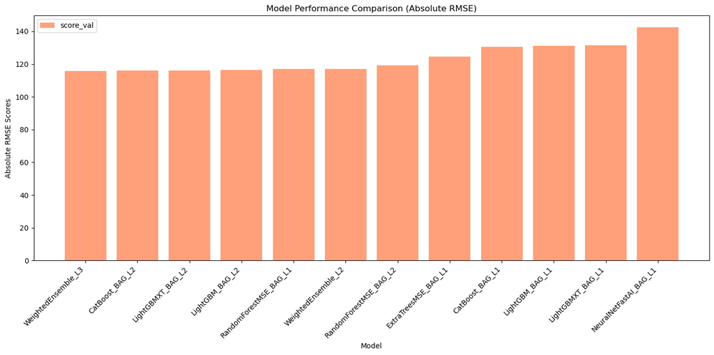

```python
import matplotlib.pyplot as plt

# Assuming 'leaderboard_df' is your DataFrame
models = leaderboard_df['model']
scores = leaderboard_df['score_val']

# Create a figure and an axis
fig, ax = plt.subplots(figsize=(14, 7))

# Plot the bars using absolute scores and 'lightsalmon' color
# We use abs() to ensure the bars plot upwards from 0
ax.bar(
    models,
    scores.abs(),
    color='lightsalmon'
)

# Set X-axis labels and rotate them for readability
ax.set_xlabel("Model")
ax.set_ylabel("Absolute RMSE Scores")
ax.set_title("Model Performance Comparison (Absolute RMSE)")
plt.xticks(rotation=45, ha='right')
ax.legend(['score_val'])

plt.tight_layout() # Adjust layout to prevent labels from overlapping
plt.show()
```

### Create predictions from test dataset

```python
predictions = predictor.predict(test)
predictions.head()
```

```
0    81.708847
1    81.196259
2    81.196259
3    95.865479
4    95.865479
Name: count, dtype: float32
```

#### NOTE: Kaggle will reject the submission if we don't set everything to be > 0.

```python
# Describe the `predictions` series to see if there are any negative values
predictions.describe()
```

```
count    6493.000000
mean      218.833374
std       126.564674
min        15.593138
25%       120.412399
50%       196.542572
75%       302.706543
max       629.248047
Name: count, dtype: float64
```

```python
# How many negative values do we have?
# Since the minimum value is 15.593138 we can safely assume that there are not negative values
# but still if we have to verify
total_predictions_count = len(predictions)
pred_Ncount = (predictions < 0).sum()
pred_Pcount = (predictions >= 0).sum()

print("Total predictions                :", total_predictions_count)
print("Total positive prediction values :", pred_Pcount)
print("Total negative prediction values :", pred_Ncount)
```

```
Total predictions                : 6493
Total positive prediction values : 6493
Total negative prediction values : 0
```

```python
# Set them to zero
# guardrails incase there are negative values
predictions[predictions < 0] = 0

# Check for any remaining negative values
predictions_neg_count = (predictions < 0).sum()

print(f"Number of remaining negative predictions: {predictions_neg_count}")
print("All negative values have been successfully clipped to zero.")
```

```
Number of remaining negative predictions: 0
All negative values have been successfully clipped to zero.
```

### Set predictions to submission dataframe, save, and submit

```python
submission["count"] = predictions
submission.to_csv("submission.csv", index=False)
```

```python
!kaggle competitions submit -c bike-sharing-demand -f submission.csv -m "first raw submission"
```

```
Successfully submitted to Bike Sharing Demand
```

#### View submission via the command line or in the web browser under the competition's page - `My Submissions`

```python
!pip install --upgrade kaggle
```

```python
!kaggle competitions submissions -c bike-sharing-demand | tail -n +1 | head -n 3
```

[output not shown]

```python
!kaggle --version
```

```
Kaggle API 1.8.2
```

```python
from kaggle.api.kaggle_api_extended import KaggleApi

api = KaggleApi()
api.authenticate()
subs = api.competition_submissions('bike-sharing-demand')  # no page_number
import json

for s in subs[:3]:
    print(json.dumps(vars(s), indent=2, sort_keys=True, default=str))
    print("-" * 40)
```

```
{
  "_date": "2025-12-07 16:00:57.423000",
  "_description": "first raw submission",
  "_error_description": null,
  "_file_name": "submission.csv",
  "_is_frozen": true,
  "_private_score": "1.42139",
  "_public_score": "1.42139",
  "_ref": 48843618,
  "_status": "SubmissionStatus.COMPLETE",
  "_submitted_by": "brejeshbalakrishnan",
  "_submitted_by_ref": "brejeshbalakrishnan",
  "_team_name": "Brejesh Balakrishnan",
  "_total_bytes": 192955,
  "_url": "/submissions/48843618/48843618.raw"
}
----------------------------------------
```

#### Initial score of `1.42139`

## Step 4: Exploratory Data Analysis and Creating an additional feature

- Any additional feature will do, but a great suggestion would be to separate out the datetime into hour, day, or month parts.

```
array([[<Axes: title={'center': 'datetime'}>,
        <Axes: title={'center': 'season'}>,
        <Axes: title={'center': 'holiday'}>],
       [<Axes: title={'center': 'workingday'}>,
        <Axes: title={'center': 'weather'}>,
        <Axes: title={'center': 'temp'}>],
       [<Axes: title={'center': 'atemp'}>,
        <Axes: title={'center': 'humidity'}>,
        <Axes: title={'center': 'windspeed'}>],
       [<Axes: title={'center': 'casual'}>,
        <Axes: title={'center': 'registered'}>,
        <Axes: title={'center': 'count'}>]], dtype=object)
```

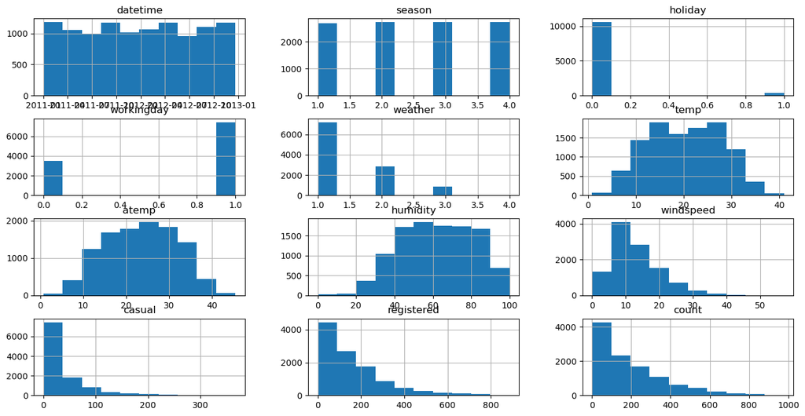

```python
# Create a histogram of all features to show the distribution of each one relative to the data. This is part of the exploritory data analysis
train.hist(figsize=(16,8))
```

#### Plot Heatmap using Correlation Matrix

[figure not shown]

```python
import matplotlib.pyplot as plt
import seaborn as sns
import numpy as np

plt.figure(figsize=(15, 15), dpi=120)
corr_data = train.copy()
correlation_matrix = corr_data.corr()
figure_plot, axes_heatmap = plt.subplots(figsize=(15, 15), dpi=120)
upper_triangle_mask = np.array(correlation_matrix)
upper_triangle_mask[np.tril_indices_from(upper_triangle_mask)] = False
axes_heatmap = sns.heatmap(correlation_matrix, cmap='GnBu', cbar_kws={"shrink": .5}, vmin=-1, vmax=1, center=0,
            square=True, mask=upper_triangle_mask, annot=True, linewidths=0.01, annot_kws={"size":13})
plt.xticks(fontsize=14, rotation=90)
plt.yticks(fontsize=14, rotation=0)
plt.title("HeatMap: Feature Correlation Matrix", fontsize=20, fontweight='bold')
plt.tight_layout()
plt.autoscale()
plt.show()
```

```python
# create a new feature
train = pd.concat([train,pd.DataFrame({
                     'year' : train.datetime.dt.year,
                     'month': train.datetime.dt.month,
                     'day': train.datetime.dt.day,
                     'hour': train.datetime.dt.hour})],axis=1)
test = pd.concat([test,pd.DataFrame({
                     'year' : test.datetime.dt.year,
                     'month': test.datetime.dt.month,
                     'day': test.datetime.dt.day,
                     'hour': test.datetime.dt.hour})],axis=1)
```

## Make category types for these so models know they are not just numbers

- AutoGluon originally sees these as ints, but in reality they are int representations of a category.
- Setting the dtype to category will classify these as categories in AutoGluon.

```python
# Recheck datatype of features in the train dataset
train.info()
```

[output not shown]

```python
train["season"] = train.season.astype('category')
train["weather"] = train.weather.astype('category')
test["season"] = test.season.astype('category')
test["weather"] = test.weather.astype('category')
```

```python
# View are new feature
train.head()
```

|  | datetime | season | holiday | workingday | weather | temp | atemp | humidity | windspeed | casual | registered | count | year | month | day | hour | year | month | day | hour |
| --- | --- | --- | --- | --- | --- | --- | --- | --- | --- | --- | --- | --- | --- | --- | --- | --- | --- | --- | --- | --- |
| 0 | 2011-01-01 00:00:00 | 1 | 0 | 0 | 1 | 9.84 | 14.395 | 81 | 0.0 | 3 | 13 | 16 | 2011 | 1 | 1 | 0 | 2011 | 1 | 1 | 0 |
| 1 | 2011-01-01 01:00:00 | 1 | 0 | 0 | 1 | 9.02 | 13.635 | 80 | 0.0 | 8 | 32 | 40 | 2011 | 1 | 1 | 1 | 2011 | 1 | 1 | 1 |
| 2 | 2011-01-01 02:00:00 | 1 | 0 | 0 | 1 | 9.02 | 13.635 | 80 | 0.0 | 5 | 27 | 32 | 2011 | 1 | 1 | 2 | 2011 | 1 | 1 | 2 |
| 3 | 2011-01-01 03:00:00 | 1 | 0 | 0 | 1 | 9.84 | 14.395 | 75 | 0.0 | 3 | 10 | 13 | 2011 | 1 | 1 | 3 | 2011 | 1 | 1 | 3 |
| 4 | 2011-01-01 04:00:00 | 1 | 0 | 0 | 1 | 9.84 | 14.395 | 75 | 0.0 | 0 | 1 | 1 | 2011 | 1 | 1 | 4 | 2011 | 1 | 1 | 4 |

```python
# View histogram of all features again now with the hour feature
train.head()
```

|  | datetime | season | holiday | workingday | weather | temp | atemp | humidity | windspeed | casual | registered | count | year | month | day | hour | year | month | day | hour |
| --- | --- | --- | --- | --- | --- | --- | --- | --- | --- | --- | --- | --- | --- | --- | --- | --- | --- | --- | --- | --- |
| 0 | 2011-01-01 00:00:00 | 1 | 0 | 0 | 1 | 9.84 | 14.395 | 81 | 0.0 | 3 | 13 | 16 | 2011 | 1 | 1 | 0 | 2011 | 1 | 1 | 0 |
| 1 | 2011-01-01 01:00:00 | 1 | 0 | 0 | 1 | 9.02 | 13.635 | 80 | 0.0 | 8 | 32 | 40 | 2011 | 1 | 1 | 1 | 2011 | 1 | 1 | 1 |
| 2 | 2011-01-01 02:00:00 | 1 | 0 | 0 | 1 | 9.02 | 13.635 | 80 | 0.0 | 5 | 27 | 32 | 2011 | 1 | 1 | 2 | 2011 | 1 | 1 | 2 |
| 3 | 2011-01-01 03:00:00 | 1 | 0 | 0 | 1 | 9.84 | 14.395 | 75 | 0.0 | 3 | 10 | 13 | 2011 | 1 | 1 | 3 | 2011 | 1 | 1 | 3 |
| 4 | 2011-01-01 04:00:00 | 1 | 0 | 0 | 1 | 9.84 | 14.395 | 75 | 0.0 | 0 | 1 | 1 | 2011 | 1 | 1 | 4 | 2011 | 1 | 1 | 4 |

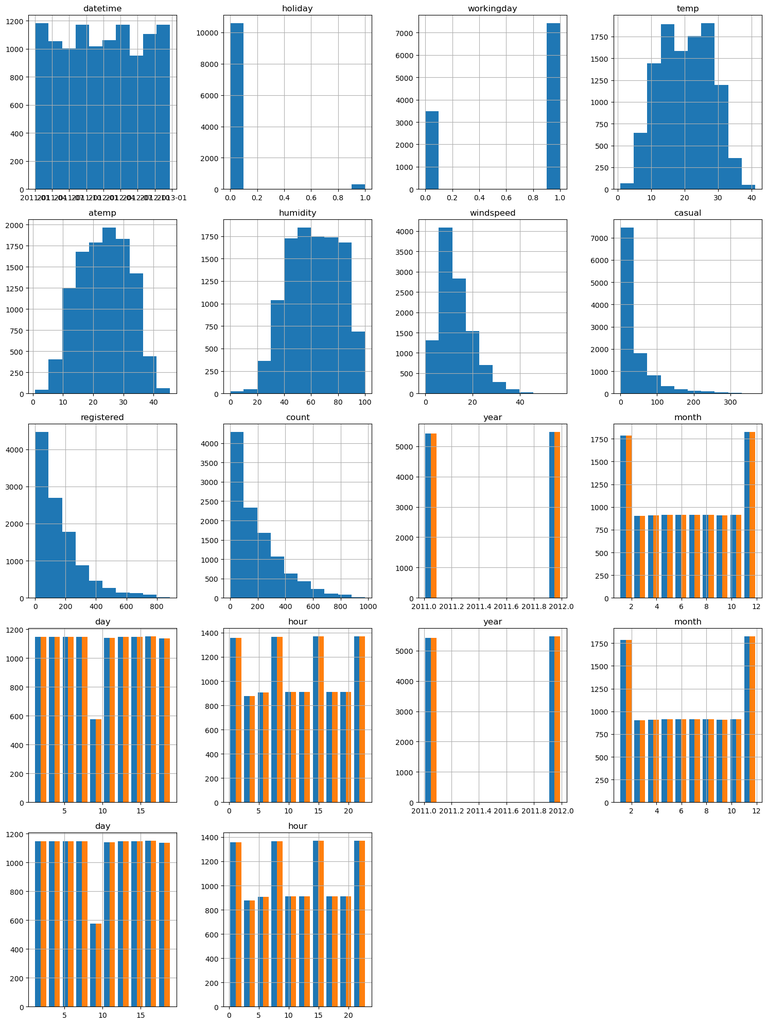

```python
# View histogram of all features again now with the hour feature
train.hist(figsize=(15,20))  # Note: 'casual' and 'registered' are ignored during training as they are absent in test data

plt.tight_layout()
plt.show()
```

```python
predictor_new_features = TabularPredictor(label=label,
                                          problem_type= 'regression',
                                          eval_metric=eval_metric,
                                          learner_kwargs={'ignored_columns': ignored_columns}).fit(
                                                                                           train_data = train_data,
                                                                                           time_limit=time_limit,
                                                                                           presets=presets,
                                                                                           dynamic_stacking=False,  # Turn off the heavy memory check
                                                                                           num_stack_levels=0)
```

[output not shown]

[output cut: 277 more lines]

[output not shown]

```python
predictor_new_features.fit_summary()
```

```
*** Summary of fit() ***
Estimated performance of each model:
                    model   score_val              eval_metric  pred_time_val    fit_time  pred_time_val_marginal  fit_time_marginal  stack_level  can_infer  fit_order
0     WeightedEnsemble_L2 -119.918835  root_mean_squared_error       0.293488  372.804507                0.000870           0.045973            2       True          8
1  RandomForestMSE_BAG_L1 -120.169502  root_mean_squared_error       0.210456    2.440768                0.210456           2.440768            1       True          3
2    ExtraTreesMSE_BAG_L1 -128.125420  root_mean_squared_error       0.129230    1.044748                0.129230           1.044748            1       True          5
3         CatBoost_BAG_L1 -130.472284  root_mean_squared_error       0.070377  313.350754                0.070377         313.350754            1       True          4
4    CatBoost_r177_BAG_L1 -131.184374  root_mean_squared_error       0.044790   83.423699                0.044790          83.423699            1       True          7
5         LightGBM_BAG_L1 -177.944936  root_mean_squared_error       0.010209   53.146978                0.010209          53.146978            1       True          2
6       LightGBMXT_BAG_L1 -178.751833  root_mean_squared_error       0.011785   56.967011                0.011785          56.967011            1       True          1
7    LightGBMLarge_BAG_L1 -178.940684  root_mean_squared_error       0.013571   53.875580                0.013571          53.875580            1       True          6
Number of models trained: 8
Types of models trained:
{'StackerEnsembleModel_LGB', 'StackerEnsembleModel_CatBoost', 'StackerEnsembleModel_RF', 'WeightedEnsembleModel', 'StackerEnsembleModel_XT'}
Bagging used: True  (with 8 folds)
Multi-layer stack-ensembling used: False
Feature Metadata (Processed):
(raw dtype, special dtypes):
('float', [])                : 3 | ['temp', 'atemp', 'windspeed']
('int', [])                  : 3 | ['season', 'weather', 'humidity']
('int', ['bool'])            : 2 | ['holiday', 'workingday']
('int', ['datetime_as_int']) : 5 | ['datetime', 'datetime.year', 'datetime.month', 'datetime.day', 'datetime.dayofweek']
Plot summary of models saved to file: /home/sagemaker-user/udacity-AWS-ml-engineer-nanodegree/project/AutogluonModels/ag-20251207_163323/SummaryOfModels.html
*** End of fit() summary ***
```

[output not shown]

[output cut: 83 more lines]

```
 3  313.350754                0.070377         313.350754            1
 4   83.423699                0.044790          83.423699            1
 5   53.146978                0.010209          53.146978            1
 6   56.967011                0.011785          56.967011            1
 7   53.875580                0.013571          53.875580            1

    can_infer  fit_order
 0       True          8
 1       True          3
 2       True          5
 3       True          4
 4       True          7
 5       True          2
 6       True          1
 7       True          6  }
```

```python
# Leaderboard dataframe
leaderboard_new_features_df = pd.DataFrame(predictor_new_features.leaderboard(silent=True))
leaderboard_new_features_df
```

|  | model | score_val | eval_metric | pred_time_val | fit_time | pred_time_val_marginal | fit_time_marginal | stack_level | can_infer | fit_order |
| --- | --- | --- | --- | --- | --- | --- | --- | --- | --- | --- |
| 0 | WeightedEnsemble_L2 | -119.918835 | root_mean_squared_error | 0.293488 | 372.804507 | 0.000870 | 0.045973 | 2 | True | 8 |
| 1 | RandomForestMSE_BAG_L1 | -120.169502 | root_mean_squared_error | 0.210456 | 2.440768 | 0.210456 | 2.440768 | 1 | True | 3 |
| 2 | ExtraTreesMSE_BAG_L1 | -128.125420 | root_mean_squared_error | 0.129230 | 1.044748 | 0.129230 | 1.044748 | 1 | True | 5 |
| 3 | CatBoost_BAG_L1 | -130.472284 | root_mean_squared_error | 0.070377 | 313.350754 | 0.070377 | 313.350754 | 1 | True | 4 |
| 4 | CatBoost_r177_BAG_L1 | -131.184374 | root_mean_squared_error | 0.044790 | 83.423699 | 0.044790 | 83.423699 | 1 | True | 7 |
| 5 | LightGBM_BAG_L1 | -177.944936 | root_mean_squared_error | 0.010209 | 53.146978 | 0.010209 | 53.146978 | 1 | True | 2 |
| 6 | LightGBMXT_BAG_L1 | -178.751833 | root_mean_squared_error | 0.011785 | 56.967011 | 0.011785 | 56.967011 | 1 | True | 1 |
| 7 | LightGBMLarge_BAG_L1 | -178.940684 | root_mean_squared_error | 0.013571 | 53.875580 | 0.013571 | 53.875580 | 1 | True | 6 |

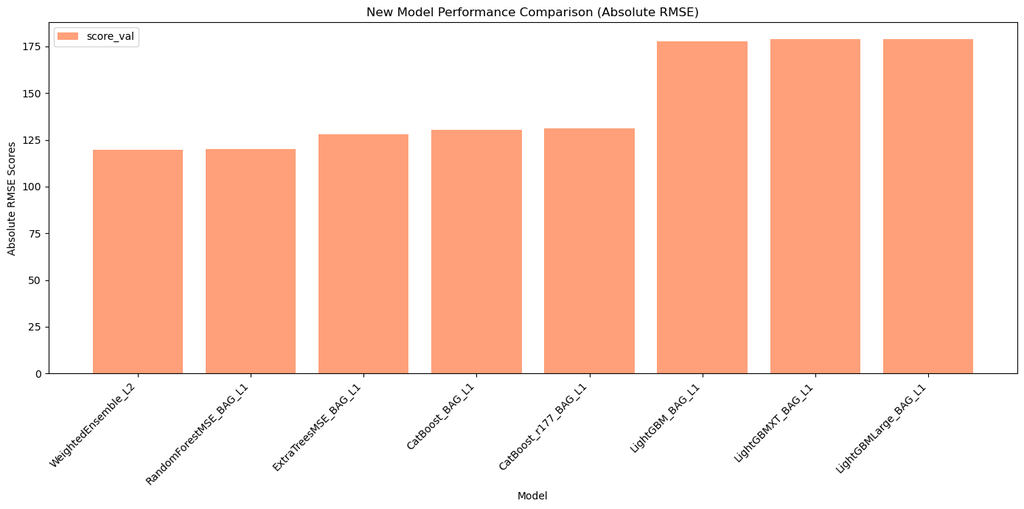

```python
# Assuming 'leaderboard_df' is your DataFrame
models = leaderboard_new_features_df['model']
scores = leaderboard_new_features_df['score_val']

# Create a figure and an axis
fig, ax = plt.subplots(figsize=(14, 7))

# Plot the bars using absolute scores and 'lightsalmon' color
# We use abs() to ensure the bars plot upwards from 0
ax.bar(
    models,
    scores.abs(),
    color='lightsalmon'
)

# Set X-axis labels and rotate them for readability
ax.set_xlabel("Model")
ax.set_ylabel("Absolute RMSE Scores")
ax.set_title("New Model Performance Comparison (Absolute RMSE)")
plt.xticks(rotation=45, ha='right')
ax.legend(['score_val'])

plt.tight_layout() # Adjust layout to prevent labels from overlapping
plt.show()
```

```python
predictions_new_features = predictor_new_features.predict(test)
predictions_new_features.head()
```

```
0    90.126976
1    75.239059
2    75.239059
3    89.350655
4    89.350655
Name: count, dtype: float32
```

```python
# Remember to set all negative values to zero
predictions_new_features.describe()
```

```
count    6493.000000
mean      217.399445
std       126.659805
min        17.851311
25%       120.187096
50%       188.148270
75%       292.530701
max       686.759705
Name: count, dtype: float64
```

```python
predictions_new_features[predictions_new_features<0] = 0    # (In case, if negative values exist in the predictions_new_features, set them to 0)

# Rechecking, if no predictions are less than 0
negative_pred_count = predictions_new_features.apply(lambda x: 1 if x<0 else 0)
pred_neg_count = (negative_pred_count==1).sum()
print(f"No. of negative predictions: {pred_neg_count}")
print("All negative values in the predictions (if any) are set to zero successfully.")
```

```
No. of negative predictions: 0
All negative values in the predictions (if any) are set to zero successfully.
```

```python
predictions_new_features.head()
```

```
0    90.126976
1    75.239059
2    75.239059
3    89.350655
4    89.350655
Name: count, dtype: float32
```

```python
submission_new_features = pd.read_csv('sampleSubmission.csv', parse_dates=["datetime"])
submission_new_features["count"] = predictions_new_features
submission_new_features.to_csv("submission_new_features.csv", index=False)
```

```python
!kaggle competitions submit -c bike-sharing-demand -f submission_new_features.csv -m "new features"
```

```
Successfully submitted to Bike Sharing Demand
```

```python
from kaggle.api.kaggle_api_extended import KaggleApi

api = KaggleApi()
api.authenticate()
subs = api.competition_submissions('bike-sharing-demand')  # no page_number
import json

for s in subs[0:3]:
    print(json.dumps(vars(s), indent=2, sort_keys=True, default=str))
    print("-" * 40)
```

```
{
  "_date": "2025-12-07 16:48:56.703000",
  "_description": "new features",
  "_error_description": null,
  "_file_name": "submission_new_features.csv",
  "_is_frozen": true,
  "_private_score": "1.41560",
  "_public_score": "1.41560",
  "_ref": 48844886,
  "_status": "SubmissionStatus.COMPLETE",
  "_submitted_by": "brejeshbalakrishnan",
  "_submitted_by_ref": "brejeshbalakrishnan",
  "_team_name": "Brejesh Balakrishnan",
  "_total_bytes": 192883,
  "_url": "/submissions/48844886/48844886.raw"
}
----------------------------------------
{
  "_date": "2025-12-07 16:45:44.443000",
  "_description": "new features",
  "_error_description": null,
  "_file_name": "submission_new_features.csv",
  "_is_frozen": true,
  "_private_score": "1.41560",
  "_public_score": "1.41560",
  "_ref": 48844797,
  "_status": "SubmissionStatus.COMPLETE",
  "_submitted_by": "brejeshbalakrishnan",
  "_submitted_by_ref": "brejeshbalakrishnan",
  "_team_name": "Brejesh Balakrishnan",
  "_total_bytes": 192883,
  "_url": "/submissions/48844797/48844797.raw"
}
----------------------------------------
{
  "_date": "2025-12-07 16:44:56.420000",
  "_description": "new features",
  "_error_description": null,
  "_file_name": "submission_new_features.csv",
  "_is_frozen": true,
  "_private_score": "1.41560",
  "_public_score": "1.41560",
  "_ref": 48844776,
  "_status": "SubmissionStatus.COMPLETE",
  "_submitted_by": "brejeshbalakrishnan",
  "_submitted_by_ref": "brejeshbalakrishnan",
  "_team_name": "Brejesh Balakrishnan",
  "_total_bytes": 192883,
  "_url": "/submissions/48844776/48844776.raw"
}
----------------------------------------
```

#### New Score of `1.41560`

## Step 6: Hyper parameter optimization

- There are many options for hyper parameter optimization.
- Options are to change the AutoGluon higher level parameters or the individual model hyperparameters.
- The hyperparameters of the models themselves that are in AutoGluon. Those need the `hyperparameter` and `hyperparameter_tune_kwargs` arguments.

```python
import autogluon.core as ag
from autogluon.common import space


# Define the dictionary for the GBMLarge preset
gbm_large_preset = {
    "learning_rate": 0.03,
    "num_leaves": 128,
    "feature_fraction": 0.9,
    "min_data_in_leaf": 3,
    # Priority 0 ensures it doesn't interfere with your custom HPO trial priority
    "ag_args": {"name_suffix": "Large", "priority": 0, "hyperparameter_tune_kwargs": None},
}

# Exclude ['NN_TORCH'] family of models
excluded_model_types = ['NN_TORCH']

# For GBM
gbm_options = [
    { # Custom HPO Trial Configuration
        'extra_trees': True,
        'num_boost_round': space.Int(lower=100, upper=800, default=100),
        'num_leaves': space.Int(lower=26, upper=66, default=36),
        'ag_args': {'name_suffix': 'XT'}
    },
    {}, # Default Configuration (to train a baseline GBM)
    gbm_large_preset # ⬅️ FIX: Use the dictionary instead of the string 'GBMLarge'
]

# XT Models
xt_options = {'criterion': 'squared_error', 'ag_args': {'name_suffix': 'MSE', 'problem_types': ['regression']}}

# XGB Models
xgb_options = [{'objective': 'reg:squarederror',
                'eval_metric': 'rmse',
                'max_depth': space.Int(lower=5, upper=8, default=6),
                'n_estimators': space.Int(lower=100, upper=500, default=100),
                'eta': .3,
                'subsample': 1,
                'colsample_bytree': 1}]

hyperparameters = {
    'GBM': gbm_options,
    'XT': xt_options,
    'XGB': xgb_options
}

num_trials = 20
search_strategy = 'auto'
scheduler = 'local'

hyperparameter_tune_kwargs = {
                             'num_trials': num_trials,
                             'scheduler' : scheduler,
                             'searcher': search_strategy,
                             }
```

```python
predictor_new_hpo = TabularPredictor(label='count', problem_type='regression', eval_metric='root_mean_squared_error',
                                    learner_kwargs={'ignored_columns': ignored_columns}).fit(
                                                                         train_data=train,
                                                                         time_limit=time_limit,
                                                                         presets=presets,
                                                                         hyperparameters=hyperparameters,
                                                                         hyperparameter_tune_kwargs=hyperparameter_tune_kwargs,
                                                                         excluded_model_types=excluded_model_types,
                                                                         refit_full='best',
                                                                                           dynamic_stacking=False,  # Turn off the heavy memory check
                                                                                           num_stack_levels=0)
```

[output not shown]

[output cut: 21 more lines]

```
	13 features in original data used to generate 15 features in processed data.
	Train Data (Processed) Memory Usage: 0.76 MB (0.2% of available memory)
Data preprocessing and feature engineering runtime = 1.17s ...
AutoGluon will gauge predictive performance using evaluation metric: 'root_mean_squared_error'
	This metric's sign has been flipped to adhere to being higher_is_better. The metric score can be multiplied by -1 to get the metric value.
	To change this, specify the eval_metric parameter of Predictor()
User-specified model hyperparameters to be fit:
{
	'GBM': [{'extra_trees': True, 'num_boost_round': Int: lower=100, upper=800, 'num_leaves': Int: lower=26, upper=66, 'ag_args': {'name_suffix': 'XT'}}, {}, {'learning_rate': 0.03, 'num_leaves': 128, 'feature_fraction': 0.9, 'min_data_in_leaf': 3, 'ag_args': {'name_suffix': 'Large', 'priority': 0, 'hy…
	'XT': [{'criterion': 'squared_error', 'ag_args': {'name_suffix': 'MSE', 'problem_types': ['regression']}}],
	'XGB': [{'objective': 'reg:squarederror', 'eval_metric': 'rmse', 'max_depth': Int: lower=5, upper=8, 'n_estimators': Int: lower=100, upper=500, 'eta': 0.3, 'subsample': 1, 'colsample_bytree': 1}],
}
Excluded models: [] (Specified by `excluded_model_types`)
Fitting 5 L1 models, fit_strategy="sequential" ...
Hyperparameter tuning model: LightGBMXT_BAG_L1 ... Tuning model for up to 107.79s of the 598.82s of remaining time.
```

[output not shown]

[output cut: 1253 more lines]

[output not shown]

[output not shown]

[output cut: 1263 more lines]

[output not shown]

[output not shown]

[output cut: 1312 more lines]

```
	Ensemble Weights: {'ExtraTreesMSE_BAG_L1': 1.0}
	-39.9538	 = Validation score   (-root_mean_squared_error)
	0.01s	 = Training   runtime
	0.0s	 = Validation runtime
AutoGluon training complete, total runtime = 167.69s ... Best model: WeightedEnsemble_L2 | Estimated inference throughput: 85341.6 rows/s (10886 batch size)
Automatically performing refit_full as a post-fit operation (due to `.fit(..., refit_full=True)`
Refitting models via `predictor.refit_full` using all of the data (combined train and validation)...
	Models trained in this way will have the suffix "_FULL" and have NaN validation score.
	This process is not bound by time_limit, but should take less time than the original `predictor.fit` call.
	To learn more, refer to the `.refit_full` method docstring which explains how "_FULL" models differ from normal models.
Fitting model: ExtraTreesMSE_BAG_L1_FULL | Skipping fit via cloning parent ...
	2.18s	 = Training   runtime
	0.13s	 = Validation runtime
Refit complete, total runtime = 0.3s ... Best model: "WeightedEnsemble_L2"
TabularPredictor saved. To load, use: predictor = TabularPredictor.load("/home/sagemaker-user/udacity-AWS-ml-engineer-nanodegree/project/AutogluonModels/ag-20251207_170115")
```

```python
predictor_new_hpo.fit_summary()
```

```
*** Summary of fit() ***
Estimated performance of each model:
                       model  score_val              eval_metric  pred_time_val  fit_time  pred_time_val_marginal  fit_time_marginal  stack_level  can_infer  fit_order
0       ExtraTreesMSE_BAG_L1 -39.953761  root_mean_squared_error       0.126752  2.411394                0.126752           2.411394            1       True          1
1        WeightedEnsemble_L2 -39.953761  root_mean_squared_error       0.127558  2.418852                0.000806           0.007458            2       True          2
2  ExtraTreesMSE_BAG_L1_FULL        NaN  root_mean_squared_error       0.126752  2.180187                0.126752           2.180187            1       True          3
Number of models trained: 3
Types of models trained:
{'WeightedEnsembleModel', 'StackerEnsembleModel_XT'}
Bagging used: True  (with 8 folds)
Multi-layer stack-ensembling used: False
Feature Metadata (Processed):
(raw dtype, special dtypes):
('category', [])             : 2 | ['season', 'weather']
('float', [])                : 3 | ['temp', 'atemp', 'windspeed']
('int', [])                  : 4 | ['humidity', 'month', 'day', 'hour']
('int', ['bool'])            : 3 | ['holiday', 'workingday', 'year']
('int', ['datetime_as_int']) : 3 | ['datetime', 'datetime.year', 'datetime.dayofweek']
Plot summary of models saved to file: /home/sagemaker-user/udacity-AWS-ml-engineer-nanodegree/project/AutogluonModels/ag-20251207_170115/SummaryOfModels.html
*** End of fit() summary ***
```

[output not shown]

```python
# Assuming your DataFrame is named 'train'
duplicated_columns = train.columns[train.columns.duplicated()]

if not duplicated_columns.empty:
    print("❌ ERROR: The following columns are duplicated in your training data:")
    print(duplicated_columns.tolist())
else:
    print("✅ No duplicated columns found. (The error must stem from another manipulation.)")
```

```
❌ ERROR: The following columns are duplicated in your training data:
['year', 'month', 'day', 'hour']
```

```python
cols = train.columns
seen_names = {}
new_cols = []

# Iterate through the columns and append a counter suffix if the name is already seen
for col in cols:
    if col in seen_names:
        seen_names[col] += 1
        new_cols.append(f"{col}_{seen_names[col]}")
    else:
        seen_names[col] = 0
        new_cols.append(col)

train.columns = new_cols
print("Duplicated columns renamed successfully. New columns:", train.columns.tolist())
```

```
Duplicated columns renamed successfully. New columns: ['datetime', 'season', 'holiday', 'workingday', 'weather', 'temp', 'atemp', 'humidity', 'windspeed', 'casual', 'registered', 'count', 'year', 'month', 'day', 'hour', 'year_1', 'month_1', 'day_1', 'hour_1']
```

```python
cols = test.columns
seen_names = {}
new_cols = []

# Iterate through the columns and append a counter suffix if the name is already seen
for col in cols:
    if col in seen_names:
        seen_names[col] += 1
        new_cols.append(f"{col}_{seen_names[col]}")
    else:
        seen_names[col] = 0
        new_cols.append(col)

test.columns = new_cols
print("Duplicated columns renamed successfully. New columns:", test.columns.tolist())
```

```
Duplicated columns renamed successfully. New columns: ['datetime', 'season', 'holiday', 'workingday', 'weather', 'temp', 'atemp', 'humidity', 'windspeed', 'year', 'month', 'day', 'hour', 'year_1', 'month_1', 'day_1', 'hour_1']
```

```python
# Leaderboard dataframe
leaderboard_new_hpo1_df = pd.DataFrame(predictor_new_hpo.leaderboard(silent=True))
leaderboard_new_hpo1_df
```

|  | model | score_val | eval_metric | pred_time_val | fit_time | pred_time_val_marginal | fit_time_marginal | stack_level | can_infer | fit_order |
| --- | --- | --- | --- | --- | --- | --- | --- | --- | --- | --- |
| 0 | ExtraTreesMSE_BAG_L1 | -39.953761 | root_mean_squared_error | 0.126752 | 2.411394 | 0.126752 | 2.411394 | 1 | True | 1 |
| 1 | WeightedEnsemble_L2 | -39.953761 | root_mean_squared_error | 0.127558 | 2.418852 | 0.000806 | 0.007458 | 2 | True | 2 |
| 2 | ExtraTreesMSE_BAG_L1_FULL | NaN | root_mean_squared_error | 0.126752 | 2.180187 | 0.126752 | 2.180187 | 1 | True | 3 |

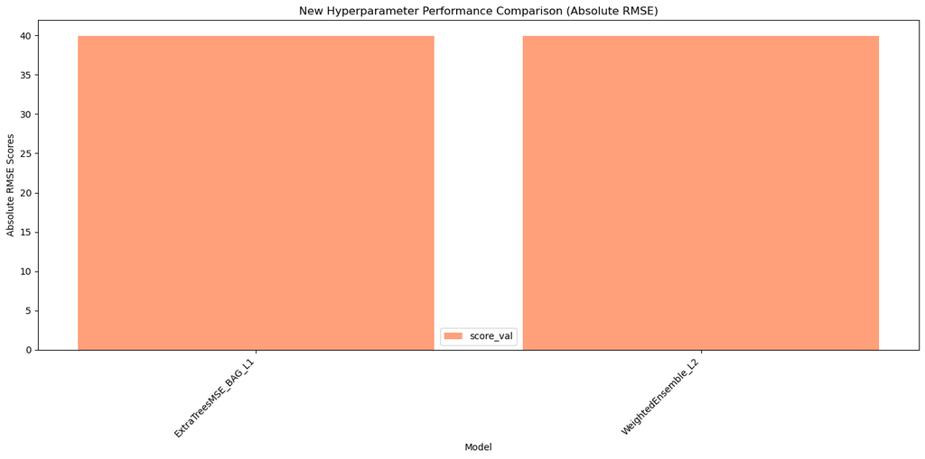

```python
# Assuming 'leaderboard_df' is your DataFrame
models = leaderboard_new_hpo1_df['model']
scores = leaderboard_new_hpo1_df['score_val']

# Create a figure and an axis
fig, ax = plt.subplots(figsize=(14, 7))

# Plot the bars using absolute scores and 'lightsalmon' color
# We use abs() to ensure the bars plot upwards from 0
ax.bar(
    models,
    scores.abs(),
    color='lightsalmon'
)

# Set X-axis labels and rotate them for readability
ax.set_xlabel("Model")
ax.set_ylabel("Absolute RMSE Scores")
ax.set_title("New Hyperparameter Performance Comparison (Absolute RMSE)")
plt.xticks(rotation=45, ha='right')
ax.legend(['score_val'])

plt.tight_layout() # Adjust layout to prevent labels from overlapping
plt.show()
```

```python
from autogluon.tabular import TabularPredictor

# after fitting predictor_new_hpo
feature_metadata = predictor_new_hpo.feature_metadata
original_features = feature_metadata.get_features()

print("✅ Successfully Retrieved Expected Input Features (Original Columns):")
print(original_features)
```

```
✅ Successfully Retrieved Expected Input Features (Original Columns):
['holiday', 'workingday', 'temp', 'atemp', 'humidity', 'windspeed', 'year', 'month', 'day', 'hour', 'season', 'weather', 'datetime', 'datetime.year', 'datetime.dayofweek']
```

```python
print("Train Columns: ",train.columns.tolist())
print("Test Columns: ",test.columns.tolist())
```

```
Train Columns:  ['datetime', 'season', 'holiday', 'workingday', 'weather', 'temp', 'atemp', 'humidity', 'windspeed', 'casual', 'registered', 'count', 'year', 'month', 'day', 'hour', 'year_1', 'month_1', 'day_1', 'hour_1']
Test Columns:  ['datetime', 'season', 'holiday', 'workingday', 'weather', 'temp', 'atemp', 'humidity', 'windspeed', 'year', 'month', 'day', 'hour', 'year_1', 'month_1', 'day_1', 'hour_1']
```

```python
import pandas as pd

# 1. Ensure 'datetime' is of datetime type (as done in the previous step)
test['datetime'] = pd.to_datetime(test['datetime'])

# 2. Manually engineer the features AG is expecting as raw input
test['datetime.year'] = test['datetime'].dt.year
test['datetime.dayofweek'] = test['datetime'].dt.dayofweek

# 3. Define the final features list (the 15 columns AG expects)
expected_features_to_keep = [
    'holiday', 'workingday', 'temp', 'atemp', 'humidity',
    'windspeed', 'year', 'month', 'day', 'hour',
    'season', 'weather', 'datetime', 'datetime.year', 'datetime.dayofweek'
]

# 4. Filter the test data to include ONLY the 15 expected columns, in order
test_final = test[expected_features_to_keep]

print(f"Test data final columns: {len(test_final.columns)}")
```

```
Test data final columns: 15
```

```python
predictions_new_hpo = predictor_new_hpo.predict(test_final)

print("\nPrediction successful! 🎉")
print(predictions_new_hpo.head())
```

```
Prediction successful! 🎉
0    11.983606
1     5.639344
2     3.721312
3     3.442623
4     2.573771
Name: count, dtype: float32
```

```python
# Remember to set all negative values to zero
# guardrails incase there are negative values
predictions_new_hpo[predictions_new_hpo < 0] = 0

# Check for any remaining negative values
predictions_neg_count = (predictions_new_hpo < 0).sum()

print(f"Number of remaining negative predictions: {predictions_neg_count}")
print("All negative values have been successfully clipped to zero.")
```

```
Number of remaining negative predictions: 0
All negative values have been successfully clipped to zero.
```

```python
# Same submitting predictions
submission_new_hpo = pd.read_csv('sampleSubmission.csv', parse_dates = ['datetime'])
submission_new_hpo["count"] = predictions_new_hpo
submission_new_hpo.to_csv("submission_new_hpo.csv", index=False)
```

```python
!kaggle competitions submit -c bike-sharing-demand -f submission_new_hpo.csv -m "new features with hyperparameters"
```

```
Successfully submitted to Bike Sharing Demand
```

```python
from kaggle.api.kaggle_api_extended import KaggleApi

api = KaggleApi()
api.authenticate()
subs = api.competition_submissions('bike-sharing-demand')  # no page_number
import json

for s in subs[0:3]:
    print(json.dumps(vars(s), indent=2, sort_keys=True, default=str))
    print("-" * 40)
```

```
{
  "_date": "2025-12-07 17:31:52.367000",
  "_description": "new features with hyperparameters",
  "_error_description": null,
  "_file_name": "submission_new_hpo.csv",
  "_is_frozen": true,
  "_private_score": "0.49145",
  "_public_score": "0.49145",
  "_ref": 48845897,
  "_status": "SubmissionStatus.COMPLETE",
  "_submitted_by": "brejeshbalakrishnan",
  "_submitted_by_ref": "brejeshbalakrishnan",
  "_team_name": "Brejesh Balakrishnan",
  "_total_bytes": 192435,
  "_url": "/submissions/48845897/48845897.raw"
}
----------------------------------------
{
  "_date": "2025-12-07 16:48:56.703000",
  "_description": "new features",
  "_error_description": null,
  "_file_name": "submission_new_features.csv",
  "_is_frozen": true,
  "_private_score": "1.41560",
  "_public_score": "1.41560",
  "_ref": 48844886,
  "_status": "SubmissionStatus.COMPLETE",
  "_submitted_by": "brejeshbalakrishnan",
  "_submitted_by_ref": "brejeshbalakrishnan",
  "_team_name": "Brejesh Balakrishnan",
  "_total_bytes": 192883,
  "_url": "/submissions/48844886/48844886.raw"
}
----------------------------------------
{
  "_date": "2025-12-07 16:45:44.443000",
  "_description": "new features",
  "_error_description": null,
  "_file_name": "submission_new_features.csv",
  "_is_frozen": true,
  "_private_score": "1.41560",
  "_public_score": "1.41560",
  "_ref": 48844797,
  "_status": "SubmissionStatus.COMPLETE",
  "_submitted_by": "brejeshbalakrishnan",
  "_submitted_by_ref": "brejeshbalakrishnan",
  "_team_name": "Brejesh Balakrishnan",
  "_total_bytes": 192883,
  "_url": "/submissions/48844797/48844797.raw"
}
----------------------------------------
```

#### New Score of `0.49145`

## Step 7: Write a Report

### Refer to the markdown file for the full report

### Creating plots and table for report

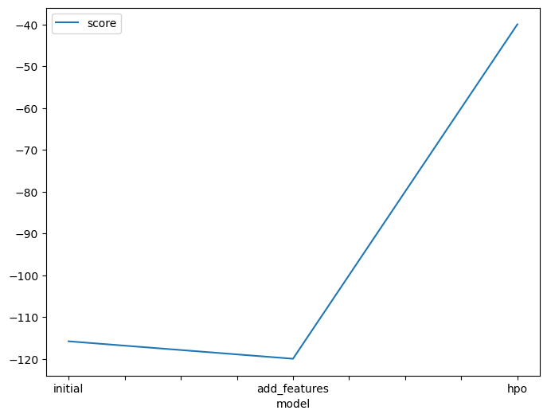

```python
# Taking the top model score from each training run and creating a line plot to show improvement
# You can create these in the notebook and save them to PNG or use some other tool (e.g. google sheets, excel)
fig = pd.DataFrame(
    {
        "model": ["initial", "add_features", "hpo"],
        "score": [predictor.leaderboard().loc[0,'score_val'],
            predictor_new_features.leaderboard().loc[0,'score_val'],
            predictor_new_hpo.leaderboard().loc[0,'score_val']]
    }
).plot(x="model", y="score", figsize=(8, 6)).get_figure()
fig.savefig('model_train_score.png')
```

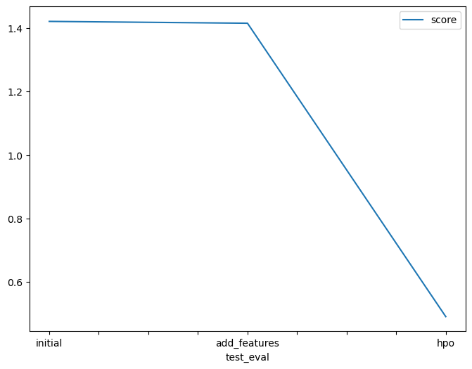

```python
# Take the 3 kaggle scores and creating a line plot to show improvement
fig = pd.DataFrame(
    {
        "test_eval": ["initial", "add_features", "hpo"],
        "score": [1.42139, 1.4156, 0.49145]
    }
).plot(x="test_eval", y="score", figsize=(8, 6)).get_figure()
fig.savefig('model_test_score.png')
```

### Hyperparameter table

```python
# The 3 hyperparameters we tuned with the kaggle score as the result
pd.DataFrame({
    "model": ["initial", "add_features", "hpo"],
    "XT": ['default', 'default', xt_options ],
    "GBM": ['default', 'default', gbm_options],
    "XGB": ['default', 'default', xgb_options ],
    "score": [1.42139, 1.4156, 0.49145]
})
```

|  | model | XT | GBM | XGB | score |
| --- | --- | --- | --- | --- | --- |
| 0 | initial | default | default | default | 1.42139 |
| 1 | add_features | default | default | default | 1.41560 |
| 2 | hpo | {'criterion': 'squared_error', 'ag_args': {'name_suffix': 'MSE', 'problem_types': ['regression']}} | [{'extra_trees': True, 'num_boost_round': Int: lower=100, upper=800, 'num_leaves': Int: lower=26, upper=66, 'ag_args': {'name_suffix': 'XT'}}, {}, {'learning_rate': 0.03, 'num_leaves': 128, 'feature_f… | [{'objective': 'reg:squarederror', 'eval_metric': 'rmse', 'max_depth': Int: lower=5, upper=8, 'n_estimators': Int: lower=100, upper=500, 'eta': 0.3, 'subsample': 1, 'colsample_bytree': 1}] | 0.49145 |

### Conclusion

The best model was **ExtraTreesMSE_BAG_L1** obtained during the hyperparameter tuning with a RMSE score of **39.953761** and the best kaggle score of **0.49145**